# Titanic_test

David Montani

4/11/2021

Dieses Dokument ist eine simple Übung basierend auf dem Datensatz der Titanic von Kaggle, welcher unter folgendem Link gefunden werden kann: https://www.kaggle.com/c/titanic

Die Ziele dieses Reports sind:

0. Import, cleaning and tidying
1. Datenanalyse
2. Bauen von Prediction Models

Als erstes wird der Datensatz importiert, sowie auf die relevanten Informationen beschränkt. Danach beginnen wir mit einer kurzen Datenanalyse (Wer hat die Titanic überlebt?) und bauen basierend auf unseren Ergebnissen Prediction Models, welche das Überleben der Passagiere vorausagt.

Dann beginnen wir doch! Als erstes importieren wir den Datensatz und untersuchen seine Struktur:

```r
titanic <- read.csv("Data/titanic_train.csv")

str(titanic)
```

```
## 'data.frame':    891 obs. of  12 variables:
##  $ PassengerId: int  1 2 3 4 5 6 7 8 9 10 ...
##  $ Survived   : int  0 1 1 1 0 0 0 0 1 1 ...
##  $ Pclass     : int  3 1 3 1 3 3 1 3 3 2 ...
##  $ Name       : Factor w/ 891 levels "Abbing, Mr. Anthony",..: 109 191 358 277 16 559 520 629 417 581 ...
##  $ Sex        : Factor w/ 2 levels "female","male": 2 1 1 1 2 2 2 2 1 1 ...
##  $ Age        : num  22 38 26 35 35 NA 54 2 27 14 ...
##  $ SibSp      : int  1 1 0 1 0 0 0 3 0 1 ...
##  $ Parch      : int  0 0 0 0 0 0 0 1 2 0 ...
##  $ Ticket     : Factor w/ 681 levels "110152","110413",..: 524 597 670 50 473 276 86 396 345 133 ...
##  $ Fare       : num  7.25 71.28 7.92 53.1 8.05 ...
##  $ Cabin      : Factor w/ 148 levels "","A10","A14",..: 1 83 1 57 1 1 131 1 1 1 ...
##  $ Embarked   : Factor w/ 4 levels "","C","Q","S": 4 2 4 4 4 3 4 4 4 2 ...
```

In den Daten haben wir also 891 Datenpunkte, die alle 12 Variablen haben. Einige der Variablen sind nicht selbsterklärend - Hier sind die Offiziellen Definitionen:

sibsp: # of siblings / spouses aboard the Titanic  
parch: # of parents / children aboard the Titanic  
ticket: Ticket number  
fare: Passenger fare  
cabin: Cabin number  
embarked: Port of Embarkation C = Cherbourg, Q = Queenstown, S = Southampton

Wir interessieren uns in den Daten nur für relevante Informationen. Wir werden deshalb einige Variablen as den Set entfernen, bevor wir die ersten Erkenntnisse aus dem Datensatz ziehen: 1. “PassengerId”, “Name”, und “Ticket” sind alles Variablen, welche keinen Wert für die Datenanalyse generieren. Diese Variablen haben für uns keinen Untersuchungswert. 2. Die Variable “Cabin number” hat nur 148 Werte und ist somit stark unvollständig. Des weiteren haben wir schon einen guten Indikator für den sozio-ökonomischen Stand der Passagiere in der Variable “Pclass” 3. Die Variable “Embarked” wird ebenfalls kaum Wertvolle Informationen für uns enthalten.

Wir entfernen also die Variablen “PassengerId”, “Name”, “Ticket”, “Cabin Number” sowie “Embarked”.

```r
titanic <- subset(titanic, select = -c(PassengerId, Name, Ticket, Cabin , Embarked))
```

Nun können wir mit unserer Datenanalyse starten!

Untersuchen wir erst einmal, ob das Sprichwort “Frauen und Kinder zuerst” auf die Titanic zutrifft:

```r
titanic$Survived <- as.factor(titanic$Survived)

titanic$Pclass <- as.factor(titanic$Pclass)

set.seed(123)
train_ind <- sample(seq_len(nrow(titanic)), size = (0.75 * nrow(titanic)))

titanic_train <- titanic[train_ind, ]

titanic_test <- titanic[-train_ind, ]


titanic_survivors <- subset(titanic_train, titanic_train$Survived == 1)
str(titanic_survivors) #256/668 in diesen Trainings-Set: Verhältnis okay
```

```
## 'data.frame':    256 obs. of  7 variables:
##  $ Survived: Factor w/ 2 levels "0","1": 2 2 2 2 2 2 2 2 2 2 ...
##  $ Pclass  : Factor w/ 3 levels "1","2","3": 3 1 1 3 1 3 1 3 2 1 ...
##  $ Sex     : Factor w/ 2 levels "female","male": 2 1 2 2 1 1 2 1 1 1 ...
##  $ Age     : num  44 44 24 20 22 20 32 38 36 47 ...
##  $ SibSp   : int  0 0 0 1 0 1 0 1 1 1 ...
##  $ Parch   : int  0 0 0 0 0 0 0 5 0 1 ...
##  $ Fare    : num  7.92 27.72 30.5 7.92 151.55 ...
```

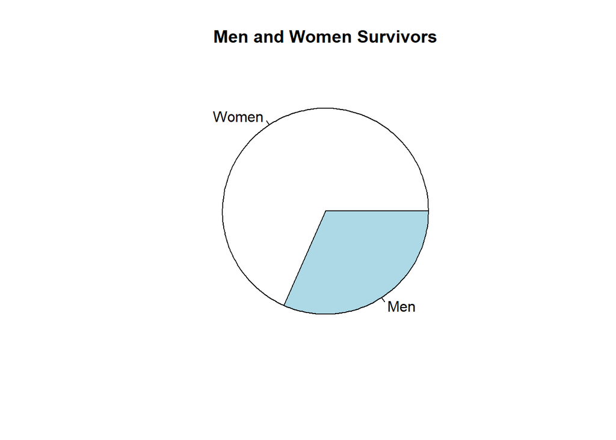

```r
women_survivors <- subset(titanic_survivors, titanic_survivors$Sex == "female")

men_survivors <- subset(titanic_survivors, titanic_survivors$Sex == "male")

slices <- c(nrow(women_survivors), nrow(men_survivors))
lbls <- c("Women", "Men")
pie(slices, labels = lbls, main="Men and Women Survivors")
```

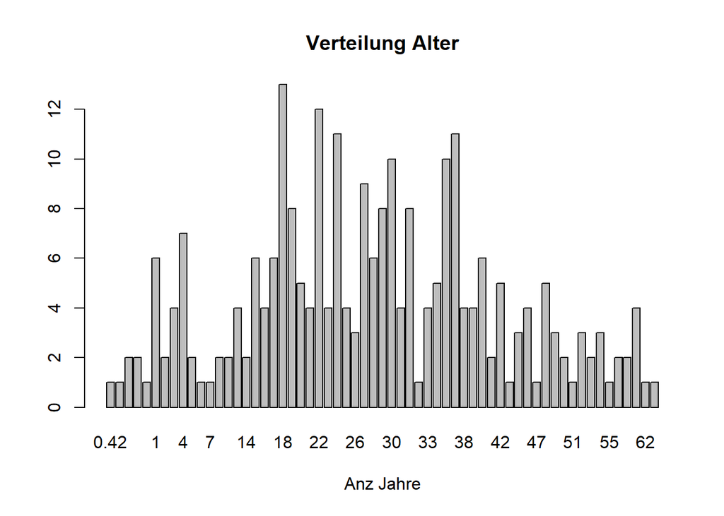

```r
counts <- table(titanic_survivors$Age)
barplot(counts, main="Verteilung Alter",
   xlab="Anz Jahre")
```

```r
mu = round(mean(titanic_survivors$Age),0)
```

Des weiteren sind wir daran Interessiert, ob Menschen aus der ersten Klasse tatsächlich bessere Überlebenschancen hatten. Wir untersuchen dazu die Variable “Pclass”:

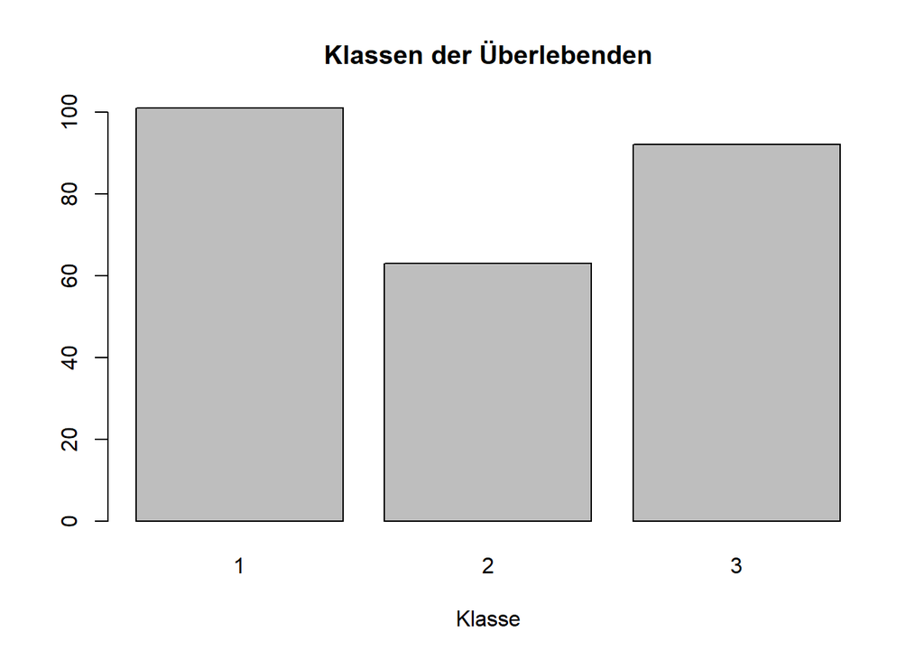

```r
class_titanic <- table(titanic_survivors$Pclass)
barplot(class_titanic, main="Klassen der Überlebenden",
   xlab="Klasse")
```

Spannenderweise besteht kein so klarer Unterschied zwischen der ersten Klasse und dem Rest: Zusätzlich haben etwas mehr Passagiere aus der dritten Klasse wie aus der zweiten Klasse überlebt - was vollkommen gegen unsere Erwartungen geht.

Mit einem schneller Blick auf die Daten lässt sich die “Titanic-Hypothese” von David Cameron nur bedingt unterstützen: Rose (Weiblich, erste Klasse) hat zwar bessere Überlebenschancen als Jack (Männlich, dritte Klasse), aber bei weitem nicht so stark wie wir sie erwartet hätten.

Wenden wir uns nun dem spannendsten Teil: Data Predictions.

Wir beginnen mit Decision Trees, ein gutes Tool für Voraussagen über Klassifikationen. Als erstes importieren wir die gebrauchten Libraries, und bauen danach einen simplen Decision Tree mit Minbuckets von 5:

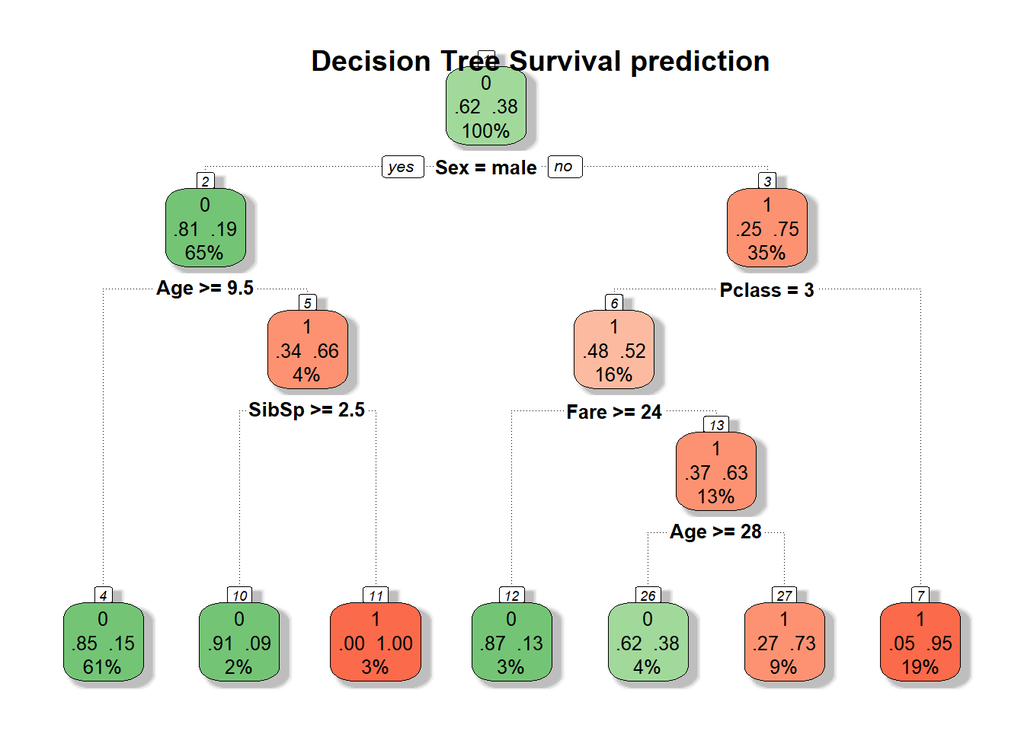

```r
titanic_train_tree <- rpart(Survived ~., method = "class", parms = list(split = "information"), minbucket = 5, minsplit = 5, data = titanic_train)

fancyRpartPlot(titanic_train_tree, main="Decision Tree Survival prediction", palettes = c("Greens", "Reds"), caption=NULL)
```

```r
titanic_predict_tree = predict(titanic_train_tree, newdata = titanic_test)



table(titanic_predict_tree[,2]>0.5, titanic_test$Survived)
```

```
##
##           0   1
##   FALSE 123  29
##   TRUE   14  57
```

```r
#Ideal cp = 0.00345, so much more specific than others. Such a low CP is needed for classification to even occur.
#Slant the cost as much as possible into the favor of predicting surviving
CostMatrix = matrix(c(0,1,1000,0), byrow=TRUE, nrow=2)
CostMatrix
```

```
##      [,1] [,2]
## [1,]    0    1
## [2,] 1000    0
```

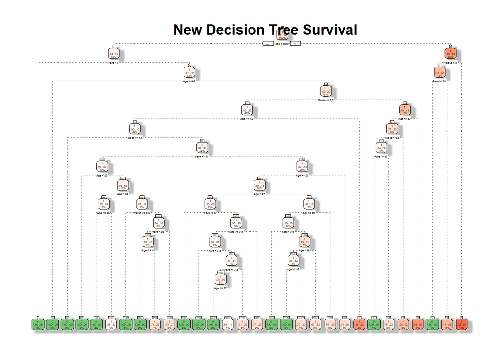

```r
titanic_tree_cv = rpart(Survived ~ ., data= titanic_train, parms=list(split="information", loss = CostMatrix), method="class", cp = 0.00345)

fancyRpartPlot(titanic_tree_cv, main=" New Decision Tree Survival", palettes = c("Greens", "Reds"), caption=NULL)
```

```r
titanic_predict_tree_cv = predict(titanic_tree_cv, newdata = titanic_test)

table(titanic_predict_tree_cv[,2]>0.5, titanic_test$Survived)
```

```
##
##           0   1
##   FALSE 107  20
##   TRUE   30  66
```

```r
# Build Random Forest Model
set.seed(123)
titanic_bags = randomForest(Survived ~ ., type="classification", data = titanic_train, ntree=1000, mtry = 6)


# Make predictions
titanic_predict_bags = predict(titanic_bags, newdata = titanic_test, type="prob")
table(titanic_predict_bags[,2]>0.5, titanic_test$Survived)
```

```
##
##           0   1
##   FALSE 115  19
##   TRUE   22  67
```

```r
accuracy_bags = (67 + 115) / (223)

precision_bags = 67 / (67 + 19)

recall_bags = 67 / (67 + 22)

accuracy_bags <- round(accuracy_bags, digits = 4)

precision_bags <- round(precision_bags, digits = 4)

recall_bags <- round(recall_bags, digits = 4)
```

```r
# Build Random Forest Model
set.seed(123)
titanic_forest = randomForest(Survived ~ ., type="classification", data = titanic_train, ntree=1000)


# Make predictions
titanic_predict_forest = predict(titanic_forest, newdata = titanic_test, type="prob")
table(titanic_predict_forest[,2]>0.5, titanic_test$Survived)
```

```
##
##           0   1
##   FALSE 122  22
##   TRUE   15  64
```

```r
print("End")
```

```
## [1] "End"
```